# LandScan Data

Mazama Science

2020-04-06

This vignette demonstrates how to create county averages from BlueSky model runs. This is particularly relevant in the COVID-19 era where health statistics are provided on a per-county basis.

### Spatial data setup

The *MazamaSpatialUtils* package is already a requirement for *AirFireModeling* and is therefore already installed. We will use datasets named `USCensusStates` and `USCensusCounties`. Each of these is a `SpatialPolygonsDataFrame` (SPDF). These are “S4” objects with per-polygon data stored in the `@data` slot.

```r
library("MazamaSpatialUtils")
setSpatialDataDir("~/Data/Spatial")

loadSpatialData("USCensusStates")
loadSpatialData("USCensusCounties")

stateCodes <- c("CA", "NV")

state_SPDF <- subset(USCensusStates, stateCode %in% stateCodes)
county_SPDF <- subset(USCensusCounties, stateCode %in% stateCodes)
```

### Load BlueSky data

The `modelBrick` object is a “RasterBrick” with 72 layers.

```r
library(AirFireModeling) # For base package support
setModelDataDir("~/Data/BlueSky")

modelBrick <-
  bluesky_load(model = 'CANSAC-1.33km', modelRun = 2020041100) %>%
  raster::crop(state_SPDF)
```

### Load LandScan data

LandScan population data is loaded as a single-layer “RasterLayer”.

```r
population <- raster::raster(path.expand("~/Data/RasterLayers/LandScanConusNight_cansac_1_33.nc"))
```

### Thematic mapping with tmap

The **tmap** package is a brilliantly simple way to make attractive plots using both raster and spatial data. It is thoroughly described at [Intro to GIS and Spatial Analysis](https://mgimond.github.io/Spatial/).

Creating a nice looking plot is very straightforward:

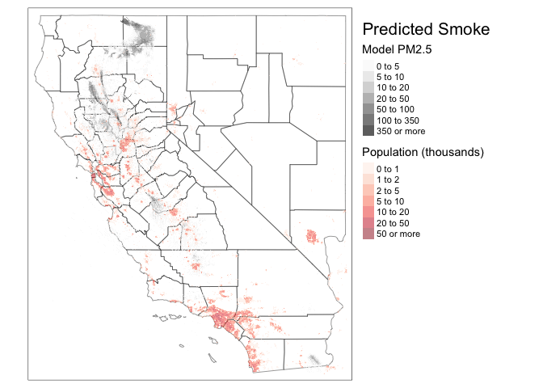

```r
library(tmap)

# Replace low values with NA to get transparency
m1 <- modelBrick[[3]]
m1_na <- m1
m1_na[m1 < 1] <- NA

p1 <- population / 1000
p1_na <- p1
p1_na[p1 < .1] <- NA

# County boundaries with raster overlay
tm_shape(county_SPDF) +
  tm_polygons(
    alpha = 0,
    border.col = adjustcolor('black', alpha = 0.4)
  ) +
  tm_shape(m1_na) +
  tm_raster(
    title = "Model PM2.5",
    colorNA = NULL,
    palette = 'Greys',
    alpha = 0.7,
    breaks = c(0, 5, 10, 20, 50, 100, 350, Inf)
    ###style = "log10_pretty"
  ) +
  tm_layout(
    title = "Predicted Smoke"
  ) +
  tm_shape(p1_na) +
  tm_raster(
    title = "Population (thousands)",
    palette = 'Reds',
    colorNA = NULL,
    alpha = 0.5,
    breaks = c(0, 1, 2, 5, 10, 20, 50, Inf)
    ###style = "log10_pretty"
  ) +
  tm_legend(outside = TRUE)
```

### Intersecting layers

Test to see if our rasters are on the same grid

```r
print(m1)
```

```
## class      : RasterLayer
## band       : 3  (of  72  bands)
## dimensions : 631, 665, 419615  (nrow, ncol, ncell)
## resolution : 0.01500001, 0.015  (x, y)
## extent     : -124.0075, -114.0325, 32.5375, 42.0025  (xmin, xmax, ymin, ymax)
## crs        : +proj=longlat +datum=WGS84 +ellps=WGS84 +towgs84=0,0,0
## source     : /private/var/folders/vd/zpgw5sv92ngdx11k5dzqz5800000gn/T/RtmpUTw7bn/raster/r_tmp_2020-05-26_122526_69749_55250.grd
## names      : X1586574000
## values     : 0, 1371.312  (min, max)
## z-value    : 1586574000
```

```r
print(p1)
```

```
## class      : RasterLayer
## dimensions : 475, 500, 237500  (nrow, ncol, ncell)
## resolution : 0.02, 0.02  (x, y)
## extent     : -124, -114, 32.5, 42  (xmin, xmax, ymin, ymax)
## crs        : +proj=longlat +a=6378137 +b=6356752.3142
## source     : memory
## names      : LandScanConusNight_cansac_1_33
## values     : 0, 85.211  (min, max)
```

In our case, the grids are not quite identical so we need to take care of that. Once they are on the same grid, we can do math on them.

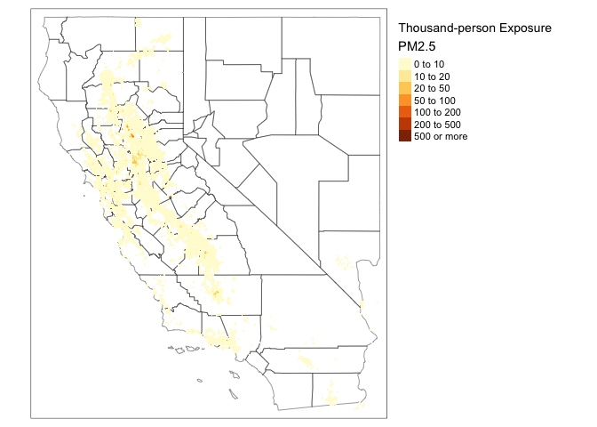

```r
# Convert p1 to the m1 grid
p2 <- raster::resample(p1, m1, method = "bilinear")

# Person-exposure per grid cell per hour
exposure <- p2 * m1
# Now "smear it out" a little
f1 <- raster::focal(
  exposure,
  w = matrix(1, nrow = 3, ncol = 3),
  fun = mean,
  pad = TRUE,
  na.rm = TRUE
)
f1_na <- f1
f1_na[f1_na < .01] <- NA

tm_shape(county_SPDF) +
  tm_polygons(
    alpha = 0,
    border.col = adjustcolor('black', alpha = 0.4)
  ) +
  tm_shape(f1_na) +
  tm_raster(
    title = "PM2.5",
    palette = 'YlOrBr',
    # To make it more dramatic
    breaks = c(0, 10, 20, 50, 100, 200, 500, Inf)
  ) +
  tm_layout(
    title = "Thousand-person Exposure"
  ) +
  tm_legend(outside = TRUE)
```

### Summarizing data

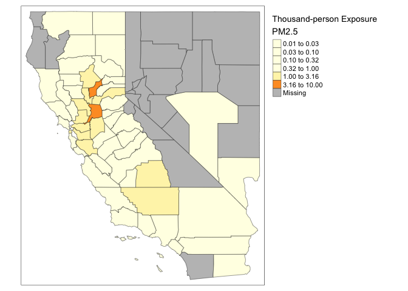

```r
# Summarize a single RasterLayer by polygon
countyExposure_SPDF <-
  raster::extract(
    f1_na,
    county_SPDF,
    fun = function(x, ...) { mean(x, ...) },
    na.rm = TRUE,
    sp = TRUE
  )

# Replace newly added column name associated with this layer
names(countyExposure_SPDF) <- c(names(county_SPDF), "exposure")

# Simple plot
tm_shape(countyExposure_SPDF) +
  tm_polygons(
    title = "PM2.5",
    col = "exposure",
    #colorNA = NULL,
    ###breaks = c(0, 1, 2, 5, 10, 20, 50, Inf),
    style = "log10_pretty",
    border.col = adjustcolor('black', alpha = 0.4)
  ) +
    tm_layout(
    title = "Thousand-person Exposure"
  ) +
  tm_legend(outside = TRUE)
```

### Adding county COVID-19 data

With COVID-19 data available by county, weighting things by COVID-19 statistics would be equally straightforward.

### Adding monitoringn data

The **tmap** package provides functions for working with point data as well so monitoring data available from **PWFSLSmoke** could be added as well.